# Block4: sample statistics

`r`r sales <- readRDS(here::here(/sales.rds)) mu <- sales %>% summarize(stat = mean(resale_price)) mu

| stat |
| --- |
| 439793.5 |

`r`r sales %>% sample_n(100) %>% summarize(stat = mean(resale_price))

| stat |
| --- |
| 435029.7 |

`r`r sample_mean <- function(data, size = 500) { data %>% sample_n(size) %>% summarize(stat = mean(resale_price)) } sampled_means <- rerun(500, sample_mean(sales)) %>% bind_rows() sampled_means %>% ggplot(aes(x = stat)) + geom_histogram() + geom_vline(xintercept=mu$stat)

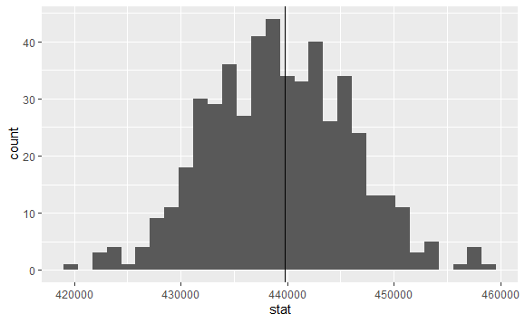

`r`r #sample of 500 (from te entire database) sales_sample <- sales %>% sample_n(500) # mean of the sample x_bar <- sales_sample %>% summarize(stat = mean(resale_price)) x_bar r sales_sample %>% specify(response = resale_price) %>% calculate(stat = )

| stat |
| --- |
| 449273.9 |

| stat |
| --- |
| 449273.9 |

`r`r # Bootstrapping bootstrapped_resale_price <- sales_sample %>% specify(response = resale_price) %>% generate(reps = 500) %>% calculate(stat = )

```
Setting `type = \bootstrap\` in `generate()`.
```

`r`r bootstrapped_resale_price %>% visualise() + geom_vline(xintercept = x_bar$stat)

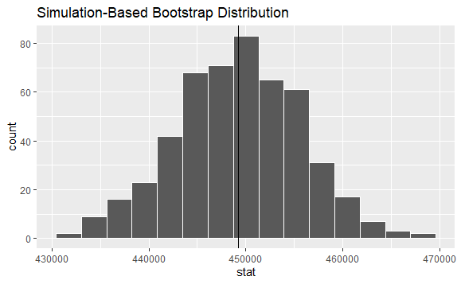

`r`r bootstrapped_resale_price %>% get_ci()

| lower_ci | upper_ci |
| --- | --- |
| 436152.1 | 461482.4 |

`r`r #Exercise 1: Using RStudioâ€™s help panel, find out how to use the standard error method with get_ci. Do you find the same values?

#Exercise 2: Try changing the value of your confidence level (by default, get_ci uses 0.95). What do you observe as you ask for higher confidence levels?

#Exercise 3: Repeat the previous steps using a different value for n, the size of our original sample. What does the new confidence interval compare to the previous one?

`r`r # Confidence intervals for subsets: #x_bar_mp_all <- sales %>% # filter(town == PARADE) %>% # summarize(stat = mean(resale_price)) #x_bar_mp

`r`r # Exercise: sales %>% #filter(floor_area_sqm == 67) %>% filter(town == PARADE) %>% View() #sample of 500 (from the entire database) sales_sample_mp <- sales %>% filter(town == PARADE) %>% sample_n(100) # Error: `size` must be less or equal than 485 (size of data), set `replace` = TRUE to use sampling with replacement. # mean of the sample x_bar_mp <- sales_sample_mp %>% summarize(stat = mean(resale_price)) x_bar_mp r bootstrapped_resale_price_mp <- sales_sample_mp %>% filter(town == PARADE) %>% specify(response = resale_price) %>% generate(reps = 500) %>% calculate(stat = )

```
Setting `type = \bootstrap\` in `generate()`.
```

`r`r bootstrapped_resale_price_mp %>% visualise() + geom_vline(xintercept = x_bar$stat)

[output not shown]

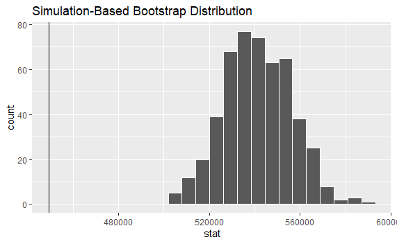

`r`r bootstrapped_resale_price_mp %>% get_ci()

| lower_ci | upper_ci |
| --- | --- |
| 513054.1 | 569803.1 |

`r`r # 4.4 Comparing means between groups

`r`r town_means <- sales %>% filter(town == | town == PARADE) %>% group_by(town) %>% summarise(mean = mean(resale_price))

`r`r town_means

| town | mean |
| --- | --- |
| MARINE PARADE | 540409.4 |
| QUEENSTOWN | 549037.4 |

`r`r ggplot() + geom_histogram( data = sales %>% filter(town == | town == PARADE), mapping = aes(x = resale_price, y = ..density.., group = town, fill = town), position = position_dodge() ) + geom_vline( data = town_means, mapping = aes(xintercept = mean, group = town, color = town) )

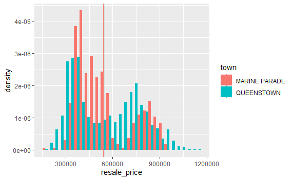

`r`r bootstrapped_resale_price_qt <- sales %>% filter(town == ) %>% specify(response = resale_price) %>% generate(reps = 100) %>% calculate(stat = )

```
Setting `type = \bootstrap\` in `generate()`.
```

`r`r bootstrapped_resale_price_qt %>% get_ci()

| lower_ci | upper_ci |
| --- | --- |
| 538626.1 | 556692.3 |

`r`r # test the significance of the difference more formally with infer

`r`r mean_diff <- sales %>% filter(town == PARADE | town == ) %>% specify(formula = resale_price ~ town) %>% calculate(stat = in means, order = c(, PARADE)) mean_diff

| stat |
| --- |
| 8627.976 |

`r`r # We then generate a set of sampled datasets. But instead of doing a simple bootstrap, we generate each sample based on the null hypothesis, namely that there is no difference between the mean of the two towns. null_distribution <- sales %>% filter(town == PARADE | town == ) %>% specify(formula = resale_price ~ town) %>% hypothesize(null = ) %>% generate(reps = 500, type = ) %>% calculate(stat = in means, order = c(, PARADE)) null_distribution %>% visualise(bins = 100) + shade_p_value(obs_stat = mean_diff, direction = )

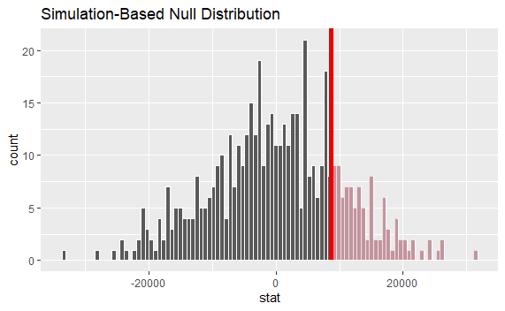

`r`r null_distribution %>% get_pvalue(obs_stat = mean_diff, direction = )

| p_value |
| --- |
| 0.202 |

`r`r sales %>% filter(town == PARADE | town == ) %>% specify(formula = resale_price ~ town) %>% # hypothesize(null = ) %>% # disable the null hypothesis generate(reps = 500, type = ) %>% # set type to bootstrap calculate(stat = in means, order = c(, PARADE)) %>% get_ci()

| lower_ci | upper_ci |
| --- | --- |
| -8736.999 | 28350.62 |

`r`r # What does the confidence interval tell you in this case? Use shade_confidence_interval to plot the CI.

# Exercise 4: In the RStudio help, find out what the direction argument does for the get_p_value and shade_p_value functions. Try setting it to both on the data above.

# Exercise 5: Are the resale prices means between Marine Parade and Bukit Timah significantly different?

# Exercise 6: During the previous week, we saw that the price of a flat can be quite different depending on what storey the flat is located on. Use the same procedure to see if the average price of 3 room flats on storey 04-06 is significantly different from 3 room flats on storey 07-09.